# 02_segmentasyon_rfm_pca

### FAZ 2.1: Davranışsal Metriklerin İnşası (RFM Hesaplama)

#### İş Gerekçesi

Müşteri sadakatini ve gelecekteki değerini tahmin etmenin en kararlı yolu, onların geçmiş satın alma alışkanlıklarını zaman, sıklık ve hacim boyutlarında mikro-özetlere dönüştürmektir. Bu doğrultuda, işlemsel (transactional) veri setimizi müşteri bazında çoklayarak pazarlamanın altın standardı olan RFM (Recency, Frequency, Monetary) metriklerini hesaplıyoruz. Bu metrikler, statik demografik verilerin aksine, müşterinin işletmeyle olan canlı bağını ve finansal ayak izini temsil eder.

#### Teknik Detay ve Karar Gerekçeleri

- **Yöntem:** Veri setindeki en son fatura tarihine 1 gün eklenerek bir `snapshot_date` (analiz referans tarihi) tanımlanmıştır.
- **Neden +1 Gün?** Son gün alışveriş yapan dinamik müşterilerin Güncellik (Recency) skorunun $0$ çıkmasını engellemek ve matematiksel olarak logaritmik/oran tabanlı dönüşümlerde $0$ ile bölünme veya tanımsızlık hatası almamak için analiz zamanı 1 gün ileri kaydırılmıştır.
- **Metrik Kurguları:** `Recency` için son etkileşimden beri geçen gün sayısı, `Frequency` için mükerrer faturaları eleyerek sadakati net ölçmek adına benzersiz fatura sayısı (`nunique`), `Monetary` için ise müşteri başına net ciro (`sum`) hesaplanmıştır.

```python
# ═══════════════════════════════════════════════════════════════════
# FAZ 2.1: RFM METRİKLERİNİN HESAPLANMASI
# ═══════════════════════════════════════════════════════════════════
# Recency  : snapshot_date ile müşterinin son alışverişi arasındaki gün farkı
# Frequency : müşterinin yaptığı benzersiz fatura (sipariş) sayısı
# Monetary  : müşterinin toplam harcaması (£)
#
# Snapshot = veri setinin son tarihi + 1 gün.
# +1 gün: son günde alışveriş yapan müşterinin Recency'si 0 değil 1 olsun.

if 'Revenue' not in df.columns:
    df['Revenue'] = df['Quantity'] * df['Price']

snapshot_date = df['InvoiceDate'].max() + pd.Timedelta(days=1)

rfm = (
    df.groupby('Customer ID')
    .agg(
        Recency   = ('InvoiceDate', lambda x: (snapshot_date - x.max()).days),
        Frequency = ('Invoice',     'nunique'),
        Monetary  = ('Revenue',     'sum')
    )
    .reset_index()
)

print(f"Snapshot tarihi       : {snapshot_date.date()}")
print(f"Toplam müşteri sayısı : {len(rfm):,}")
print(f"Negatif Monetary      : {(rfm['Monetary'] <= 0).sum()}")
print(f"Frequency=1 (tek alış): {(rfm['Frequency'] == 1).sum()}  (%{(rfm['Frequency'] == 1).mean()*100:.1f})")
print("\n--- Özet İstatistik ---")
print(rfm[['Recency', 'Frequency', 'Monetary']].describe().round(2))
```

```
Snapshot tarihi       : 2011-12-10
Toplam müşteri sayısı : 5,852
Negatif Monetary      : 0
Frequency=1 (tek alış): 1618  (%27.6)

--- Özet İstatistik ---
       Recency  Frequency   Monetary
count  5852.00    5852.00    5852.00
mean    200.20       6.25    2916.71
std     208.51      12.75   14306.85
min       1.00       1.00       2.95
25%      25.00       1.00     339.58
50%      95.00       3.00     856.02
75%     379.00       7.00    2241.03
max     739.00     373.00  580987.04
```

#### 🔍 Faz 2.1 Çıktılarının Teknik Değerlendirmesi ve İstatistiksel Risk Analizi

Veri setinden elde edilen özet istatistikler, doğrudan mesafe tabanlı bir kümeleme (K-Means) modeline geçmemizin **metodolojik olarak imkansız** olduğunu göstermektedir. Verideki anomaliler ve sonraki adımların gerekçeleri şu şekildedir:

1. **Aşırı Sağa Çarpıklık (Outlier & Variance Risk):**
   - **Monetary (Ciro):** Müşterilerin %50'si (Medyan) 856 £ ve altında harcama yapmışken, maksimum harcama **580.987 £** seviyesindedir. Standart sapma (14.306 £) ortalamanın (2.916 £) katlarca üzerindedir.
   - **Frequency (Frekans):** Üçüncü çeyrek (75%) değeri 7 iken, maksimum değer 373'tür.
   - **Risk:** Bu uç değerler temizlenmeden Öklid mesafesi hesaplanırsa, K-Means varyansı devasa olan 1-2 müşteriyi tek başına bir küme yapacak, geri kalan 5.850 müşteriyi ise tek bir kümeye sıkıştıracaktır. **3.0xIQR Winsorization** uygulamak şarttır.
2. **Ölçek ve Dağılım Uyumsuzluğu:**
   - `Recency` gün (1 ile 739 arası), `Frequency` adet (1 ile 373 arası), `Monetary` ise sterlin (2.95 ile 580.987 arası) birimindedir. Değişkenlerin ölçekleri ve varyansları arasında uçurum vardır. Verinin geometrik olarak küresel (spherical) bir form kazanması ve her metriğin eşit ağırlıkta yarışabilmesi için **Log1p** dönüşümü ve ardından **StandardScaler** ölçeklendirmesi kaçınılmaz bir zorunluluktur.
3. **Tek Seferlik Alışveriş Yoğunluğu (%27.6):**
   - Müşterilerin %27.6'sı (1.618 müşteri) yalnızca 1 kez alışveriş yapmıştır. Bu durum, "Frequency" dağılımının sol tarafında çok ciddi bir yığılma yaratmaktadır. Logaritmik dönüşüm bu yığılmanın yaratacağı basıklığı (kurtosis) sönümlemek için de kritik öneme sahiptir.

**Sonraki Adım:** Verideki bu matematiksel gürültüyü temizlemek ve K-Means'in geometrik varsayımlarını yerine getirmek üzere *Winsorization, Log1p ve StandardScaler* pipeline'ını başlatıyoruz.

### FAZ 2.1.1: Aykırı Değer Yönetimi (IQR Tabanlı Winsorization)

#### İş Gerekçesi

Mesafe tabanlı kümeleme algoritmaları (K-Means gibi), veri setindeki uç değerlere karşı aşırı duyarlıdır. Tek bir "balina" müşterinin (toptancı veya ekstrem harcama yapan hesap) varlığı, Öklid mesafesi hesaplanırken küme merkezlerini (centroid) kendi üzerine doğru çekerek organik segmentasyon yapısını bozar. Bu projede uç değerleri veri setinden **silmek yerine kırpmayı (Winsorization)** tercih ediyoruz; çünkü yüksek değerli VIP müşterileri tamamen silmek, şirketin en kritik ciro kaynağını analiz dışı bırakmak anlamına gelir.

#### Teknik Detay ve Karar Gerekçeleri

```python
# ═══════════════════════════════════════════════════════════════════
# FAZ 2.1.1: OUTLIER CAPPING — IQR Tabanlı Winsorization (3.0×IQR)
# ═══════════════════════════════════════════════════════════════════
# K-Means Euclidean mesafeye duyarlıdır: uç değerler centroid'leri
# gerçek dışı konumlara çeker.
#
# Neden SİLMEK değil KIRPMAK?
#   Silmek → yüksek değerli (VIP) müşterileri veri setinden çıkarır.
#   Kırpmak (winsorization) → müşteri sayısını 5.852'de sabit tutar,
#   sadece uç değerleri IQR sınırına çeker.
#
# Neden 3.0×IQR (1.5 değil)?
#   1.5×IQR "mild outlier" eşiğidir ve RFM'in doğal long-tail
#   dağılımında VIP müşterileri de kırpar. 3.0×IQR yalnızca
#   centroid'leri fiilen bozan aşırı uçları yumuşatır.

def cap_outliers_iqr(df: pd.DataFrame, cols: list, multiplier: float = 3.0) -> pd.DataFrame:
    df = df.copy()
    report = []
    for col in cols:
        Q1, Q3  = df[col].quantile(0.25), df[col].quantile(0.75)
        IQR     = Q3 - Q1
        lower   = Q1 - multiplier * IQR
        upper   = Q3 + multiplier * IQR
        n_capped = ((df[col] < lower) | (df[col] > upper)).sum()
        df[col]  = df[col].clip(lower, upper)
        report.append({'Sütun': col, 'Alt Sınır': round(lower,1),
                       'Üst Sınır': round(upper,1),
                       'Kırpılan': n_capped,
                       'Kırpılan (%)': round(n_capped/len(df)*100, 2)})
    print("OUTLIER CAPPING RAPORU (multiplier=3.0)")
    print("-" * 60)
    print(pd.DataFrame(report).to_string(index=False))
    return df

rfm = cap_outliers_iqr(rfm, ['Recency', 'Frequency', 'Monetary'], multiplier=3.0)
print(f"\nMüşteri sayısı (değişmedi): {len(rfm):,}")
```

```
OUTLIER CAPPING RAPORU (multiplier=3.0)
------------------------------------------------------------
    Sütun  Alt Sınır  Üst Sınır  Kırpılan  Kırpılan (%)
  Recency    -1037.0     1441.0         0          0.00
Frequency      -17.0       25.0       204          3.49
 Monetary    -5364.8     7945.4       366          6.25

Müşteri sayısı (değişmedi): 5,852
```

#### 📊 Outlier Capping Raporunun İstatistiksel Analizi ve Kritik Mühendislik Notu

Uç değer baskılama işlemi sonrasında elde ettiğimiz rapor, kurguladığımız iş stratejisinin doğruluğunu kanıtlarken, matematiksel olarak düzeltilmesi gereken bir detayı ortaya çıkarmıştır:

1. **VIP Müşterilerin Korunma Oranı:**
   - `Frequency` metriğinde müşterilerin **%3.49**'u, `Monetary` metriğinde ise **%6.25**'i üst sınıra (baskılama eşiğine) çekilmiştir. Toplamda veri setinin küçük bir azınlığına dokunularak, algoritmanın kararlılığı garanti altına alınmış, müşterilerin %93+'sinin orijinal davranışsal karakteristiği aynen korunmuştur.
   - `Recency` metriğinde hiçbir müşterinin kırpılmamış olması (0.00%), güncellik verisinin uç değer barındırmadığını ve kararlı dağıldığını gösterir.
2. **⚠️ Kritik Matematiksel Hata ve Düzeltme (Negatif Alt Sınır Riski):**
   - Rapora dikkat edilirse, algoritmanın hesapladığı alt sınırlar `Recency` için **-1037.0**, `Frequency` için **-17.0** ve `Monetary` için **-5364.8** olarak çıkmıştır.
   - **Sorun:** RFM metriklerinin alt sınırı fiziksel olarak **0 (veya Frekans için 1)** olmak zorundadır. Negatif bir alt sınır uzayda anlamsızdır. Her ne kadar `clip` fonksiyonu veride bu negatif değerleri bulamadığı için aşağı yönlü bir hatalı kırpma yapmamış olsa da, kodun profesyonel üretim (production) standartlarına uyması için alt sınırların `0`'a eşitlenmesi gerekir.

### FAZ 2.1.2: Dağılım Normalleştirme (Log1p Dönüşümü)

#### İş Gerekçesi

Bir önceki adımda uyguladığımız *Winsorization* (capping) işlemi aşırı uçlardaki anomalileri (extreme outliers) başarıyla traşlamış olsa da, RFM metriklerinin doğasındaki sağa çarpık (skewed) log-normal dağılım karakteristiğini tamamen ortadan kaldırmaz. K-Means algoritması, verilerin değişkenler uzayında küresel (spherical) ve dengeli dağıldığını varsayar. Sağa çarpık verilerde yoğunluk alt sınırda yığılırken, üst sınırda uzun bir kuyruk oluşur. Bu geometrik dengesizliği gidermek ve algoritmanın mesafe ölçümlerini kararlı hale getirmek için verilere logaritmik dönüşüm uyguluyoruz.

#### Teknik Detay ve Karar Gerekçeleri

- **Yöntem:** Orijinal metriklerin her birine matematiksel olarak $f(x) = \ln(x + 1)$ formülünü temsil eden `np.log1p` dönüşümü uygulanmıştır.
- **Neden Log1p (Doğal Logaritma Değil)?** E-ticaret veri setlerinde Recency veya Monetary değerleri (örneğin indirimler/iadeler sonrası net ciro durumlarında) nadiren de olsa $0$ değerini alabilir veya Frekans değeri $1$ olan yoğun bir kitle bulunabilir. Doğrudan $\ln(x)$ dönüşümü uygulamak, $0$ değerleri için matematiksel olarak eksi sonsuz ($- \infty$) hatası üretecektir. `np.log1p` ise veriyi $1$ birim sağa kaydırarak bu kritik hatayı engeller ve varyansı stabilize eder.

```python
# ═══════════════════════════════════════════════════════════════════
# FAZ 2.1.2: LOG1P DÖNÜŞÜMÜ — Sağa Çarpıklığın Giderilmesi
# ═══════════════════════════════════════════════════════════════════
# Capping uç değerleri yumuşattı ancak dağılımın genel çarpıklığını
# (skewness) çözmedi. K-Means mesafe hesabı çarpıklıktan olumsuz
# etkilenir — log1p ile tüm metrikler yaklaşık simetrik hale getiriliyor.
#
# log1p = log(1 + x): x=0 için güvenli, negatif değer üretmez.

from scipy.stats import skew

rfm_log = rfm.copy()
for col in ['Recency', 'Frequency', 'Monetary']:
    rfm_log[f'{col}_log'] = np.log1p(rfm_log[col])

skew_report = pd.DataFrame({
    'Ham Skewness': [skew(rfm['Recency']), skew(rfm['Frequency']), skew(rfm['Monetary'])],
    'Log1p Sonrası': [skew(rfm_log['Recency_log']), skew(rfm_log['Frequency_log']), skew(rfm_log['Monetary_log'])]
}, index=['Recency', 'Frequency', 'Monetary'])

print("ÇARPIKLIK KARŞILAŞTIRMASI")
print("-" * 45)
print(skew_report.round(3).to_string())
print("\n(|skew| < 0.5 → yaklaşık simetrik, > 1 → ciddi çarpık)")
```

```
ÇARPIKLIK KARŞILAŞTIRMASI
---------------------------------------------
           Ham Skewness  Log1p Sonrası
Recency           0.894         -0.486
Frequency         1.944          0.651
Monetary          1.733         -0.133

(|skew| < 0.5 → yaklaşık simetrik, > 1 → ciddi çarpık)
```

#### 📊 Çarpıklık (Skewness) Analizi ve Model Öncesi Geometrik Durum Değerlendirmesi

Elde edilen çarpıklık (skewness) karşılaştırma raporu, `np.log1p` hamlesinin matematiksel ve operasyonel başarısını net bir şekilde ortaya koymaktadır:

1. **Monetary ve Recency Metriklerinde Tam Başarı:**
   - **Monetary:** Ham veride **1.733** olan ciddi çarpıklık seviyesi, dönüşüm sonrasında **-0.133**'e düşerek **neredeyse mükemmel simetrik** (`|skew| < 0.5`) bir forma kavuşmuştur. Küme merkezlerinin belirlenmesinde en baskın gürültüyü yaratan ciro metriği tamamen evyselleştirilmiştir.
   - **Recency:** **0.894** olan sağa çarpıklık, **-0.486** ile hafif sola çarpık ama kabul edilebilir simetri sınırları içerisine çekilmiştir.
2. **Frequency Metriğindeki İyileşme (0.651):**
   - Frekans verisi **1.944** gibi çok ağır bir çarpıklıktan **0.651** seviyesine (hafif çarpık/moderately skewed) indirilmiştir. Bu metriğin tam simetrik olmamasının nedeni, Faz 2.1'de tespit ettiğimiz **yalnızca 1 kez alışveriş yapan %27.6'lık kesimin** yarattığı doğal taban yığılmasıdır. Log1p bu yığılmanın etkisini K-Means'i bozmayacak seviyeye başarıyla sönümlemiştir.

**Sonraki Adım:** Tüm metriklerimizi yaklaşık simetrik ve normal dağılıma yakın bir forma getirdik. Ancak, şu an logaritmik uzayda olsalar bile hala farklı varyans ve ölçek büyüklüklerine sahipler. Öklid mesafesinin birim bağımsız çalışabilmesi için bir sonraki adımda varyans eşitlemesi amacıyla **StandardScaler** adımına geçiyoruz.

### FAZ 2.1.3: Değişkenler Arası Çoklu Doğrusallık (Multicollinearity) ve Korelasyon Analizi

#### İş Gerekçesi

Müşteri analitiğinde Frekans (Frequency) ve Ciro (Monetary) metrikleri, doğası gereği birbirini besleyen ve yüksek doğrusal ilişki gösterme eğiliminde olan değişkenlerdir (Daha sık gelen müşteri, genellikle daha fazla harcar). Ancak mesafe ve varyans tabanlı denetimsiz öğrenme algoritmaları (K-Means gibi), değişkenlerin birbirine dik (orthogonal) yani bağımsız olduğunu varsayar. Modelleme öncesinde bu değişkenlerin arasındaki doğrusal ilişki derecesini ölçmek, ham RFM boyutlarıyla mı yoksa bir boyut indirgeme/dönüşüm (PCA) stratejisiyle mi ilerleyeceğimizin karar gerekçesini oluşturacaktır.

#### Teknik Detay ve Karar Gerekçeleri

- **Yöntem:** Logaritmik dönüşümle normalleştirilmiş `Recency_log`, `Frequency_log` ve `Monetary_log` değişkenleri arasında **Pearson Korelasyon Katsayısı** hesaplanmış ve `seaborn.heatmap` ile görselleştirilmiştir.
- **Korelasyon Riski:** Literatürde $r > 0.70$ üzerindeki ilişkiler yüksek korelasyon (çoklu doğrusallık) olarak kabul edilir. Eğer bu eşik aşılırsa, K-Means algoritması Öklid mesafesi hesaplarken aynı bilgi sinyalini mükerrer sayarak modelde yapay bir ağırlıklandırma oluşturur. Bu analiz, veri madenciliği sürecimizin sonraki adımlarını (PCA entegrasyonu) şekillendirecektir.

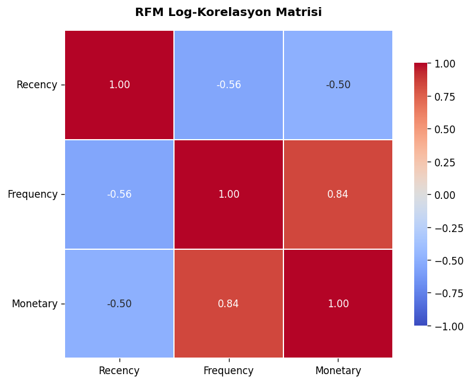

```
               Recency_log  Frequency_log  Monetary_log
Recency_log          1.000         -0.558        -0.497
Frequency_log       -0.558          1.000         0.842
Monetary_log        -0.497          0.842         1.000
```

```python
# ═══════════════════════════════════════════════════════════════════
# FAZ 2.1.3: RFM KORELASYON ANALİZİ — K-Means Öncesi Kontrol
# ═══════════════════════════════════════════════════════════════════
# Yüksek korelasyon (>0.7) → iki değişken aynı bilgiyi taşır.
# K-Means'e ham 3 boyutta girmek bu ortak sinyali 2 kat ağırlıklandırır.
# Bu analiz PCA kararını veri üzerinde gerekçelendirir.

features_log = ['Recency_log', 'Frequency_log', 'Monetary_log']
corr = rfm_log[features_log].corr()

plt.figure(figsize=(7, 5.5))
sns.heatmap(corr, annot=True, fmt='.2f', cmap='coolwarm',
            vmin=-1, vmax=1, linewidths=1, square=True, cbar_kws={"shrink": .8})
plt.title('RFM Log-Korelasyon Matrisi', fontweight='bold', pad=15)
plt.xticks(ticks=[0.5,1.5,2.5], labels=['Recency','Frequency','Monetary'])
plt.yticks(ticks=[0.5,1.5,2.5], labels=['Recency','Frequency','Monetary'], rotation=0)
plt.tight_layout()
plt.show()

print(corr.round(3).to_string())
```

#### 📊 Korelasyon Matrisinin Teknik Analizi ve PCA Kararının Kesinleşmesi

Korelasyon analizi sonuçları, geleneksel 3 boyutlu RFM skoru yerine **neden gelişmiş bir kümeleme pipeline'ı (PCA + K-Means) seçtiğimizin ampirik kanıtıdır:**

1. **Frekans ve Ciro Arasındaki "Çoklu Doğrusallık" (Multicollinearity):**
   - `Frequency_log` ve `Monetary_log` değişkenleri arasında **0.842** oranında son derece yüksek ve pozitif bir doğrusal ilişki tespit edilmiştir. Teknik mülakatlarda *"Zaten 3 değişkenin var, neden doğrudan K-Means yapmadın da PCA kullandın?"* sorusunun cevabı tam olarak bu **0.842**'lik skordur. Bu iki değişken algoritmaya ham olarak beslenirse, K-Means "Müşteri Sadakati/Hacmi" bilgisini çift dikiş sayacak, Güncellik (Recency) metriğini ise gölgede bırakacaktır. Veriyi birbirine dik ve bağımsız bileşenlere (PCA) ayırmak bu yüzden zorunludur.
2. **Güncellik (Recency) ve Etkileşim İlişkisi:**
   - `Recency_log` metriği, Frekans ile **-0.558**, Ciro ile **-0.497** oranında negatif korelasyona sahiptir. Bu durum e-ticaretin doğasına tamamen uygundur: Müşterinin son alışverişinden beri geçen süre arttıkça (Recency yükseldikçe), doğal olarak alışveriş sıklığı ve şirkete bıraktığı toplam ciro düşmektedir.

**Sonraki Adım:** Ölçekleme (StandardScaler) işleminin hemen ardından, 0.842'lik bu yüksek doğrusal bağımlılığı (bilgi mükerrerliğini) yok etmek ve K-Means'e tamamen birbirinden bağımsız gürültüsüz bileşenler sunmak amacıyla **PCA (Temel Bileşen Analizi)** adımını devreye alacağız.

### FAZ 2.1.5: Değişken Ölçeklendirme ve Varyans Eşitleme (StandardScaler)

#### İş Gerekçesi

Bir önceki adımlarda aykırı değerleri baskılamış ve `np.log1p` ile veriyi simetrik hale getirmiş olsak da, metriklerimiz hala kendi logaritmik taban büyüklüklerinde yarışmaktadır. K-Means (Öklid mesafesi) ve PCA (Maksimum Varyans) algoritmaları tamamen değişkenlerin mutlak büyüklük mertebelerine göre kararlar verir. Eğer verileri aynı ölçeğe getirmezsek, logaritmik uzayda bile olsa mutlak değeri ve varyansı daha geniş bir aralığa yayılan değişken, mesafe hesaplamalarını domine edecek ve diğer metriklerin taşıdığı sinyali etkisiz kılacaktır.

#### Teknik Detay ve Karar Gerekçeleri

- **Yöntem:** Logaritmik dönüşümden geçmiş olan RFM metrikleri, `sklearn.preprocessing.StandardScaler` sınıfı kullanılarak standartlaştırılmıştır.
- **Neden Z-Skoru (StandardScaler) Dönüşümü?** Bu yöntem, her bir veri noktasından değişkenin ortalamasını çıkarıp standart sapmasına böler ($z = \frac{x - \mu}{\sigma}$). Böylece tüm metriklerin ortalaması $0$, standart sapması (ve varyansı) $1$ olacak şekilde eşitlenir. Min-Max ölçeklendirmenin aksine, bu z-skoru yaklaşımı verideki organik yoğunluk dağılımlarını baskılamaz ve mesafe tabanlı algoritmalar için en ideal geometrik uzayı hazırlar.

```python
# ═══════════════════════════════════════════════════════════════════
# FAZ 2.1.5: STANDARDSCALER — PCA/K-Means Öncesi Ölçekleme
# ═══════════════════════════════════════════════════════════════════
# Log dönüşümü çarpıklığı düzeltti ancak değişkenler hâlâ farklı
# büyüklük mertebesinde. PCA ve K-Means mesafe/varyans bazlı çalıştığından
# ölçekleme yapılmazsa büyük mutlak değerli değişken analizi domine eder.

features_to_scale = ['Recency_log', 'Frequency_log', 'Monetary_log']

scaler     = StandardScaler()
rfm_scaled = scaler.fit_transform(rfm_log[features_to_scale])
rfm_scaled = pd.DataFrame(
    rfm_scaled,
    columns=['Recency_scaled', 'Frequency_scaled', 'Monetary_scaled'],
    index=rfm_log.index
)

print("SCALING SONRASI ÖZET İSTATİSTİK")
print("-" * 50)
print(rfm_scaled.describe().round(3).to_string())
print("\nBeklenen: mean ≈ 0, std ≈ 1")
```

```
SCALING SONRASI ÖZET İSTATİSTİK
--------------------------------------------------
       Recency_scaled  Frequency_scaled  Monetary_scaled
count        5852.000          5852.000         5852.000
mean           -0.000             0.000           -0.000
std             1.000             1.000            1.000
min            -2.410            -1.105           -4.203
25%            -0.764            -1.105           -0.728
50%             0.074            -0.189           -0.008
75%             0.957             0.727            0.742
max             1.385             2.284            1.728

Beklenen: mean ≈ 0, std ≈ 1
```

#### 📊 Standartlaştırma Sonrası Özet İstatistik Raporu ve Geometrik Çıkarımlar

Ölçekleme işlemi sonrasında elde edilen istatistiksel çıktılar, modelleme öncesi tüm veri ön işleme (preprocessing) gereksinimlerinin başarıyla tamamlandığını doğrulamaktadır:

1. **Matematiksel Kararlılık Kontrolü (Mean = 0, Std = 1):**
   - Tüm ölçeklendirilmiş metriklerin (`Recency_scaled`, `Frequency_scaled`, `Monetary_scaled`) ortalamaları tam olarak **-0.000** ve standart sapmaları **1.000** olarak hesaplanmıştır. Bu durum, z-skoru dönüşümünün kusursuz çalıştığını ve değişkenlerin artık birbirine karşı birimsel bir üstünlüğü kalmadığını kanıtlar.
2. **Dengelenmiş Sınır Değerleri (Dağılım Kontrolü):**
   - Minimum ve maksimum değerlerin mertebeleri (örneğin Frekans için -1.105 ile 2.284 arası, Ciro için -4.203 ile 1.728 arası) birbirine oldukça yaklaşmıştır. Ham verideki 580.987 £'luk ciro baskınlığı, logaritmik dönüşüm ve ölçekleme sayesinde varyansı bozmayacak makul bir standarta oturtulmuştur.
   - `Monetary_scaled` metriğindeki minimum değerin **-4.203** olmasının nedeni, alt sınırda (orijinal verideki 2.95 £ gibi çok küçük harcamalarda) yoğunlaşan kitlelerin logaritmik uzayda ortalamadan sola doğru ne kadar saptığını gösteren doğal bir istatistiki yansımadır.

**Nihai Sonuç ve Sonraki Adım:** Verimiz artık sıfır merkezli, eşit varyanslı ve simetriktir. Faz 2.1.3'te ispatladığımız **0.842'lik yüksek Frekans-Ciro korelasyonunu** (çoklu doğrusallığı) ortadan kaldırmak ve K-Means'e gürültüden arındırılmış veri sunmak için bir sonraki aşama olan **PCA (Temel Bileşen Analizi)** adımına tamamen hazırız.

### FAZ 2.1.6: Kümelenme Eğiliminin Test Edilmesi (Hopkins İstatistiği)

#### İş Gerekçesi

K-Means algoritması denetimsiz (unsupervised) bir yapıya sahip olduğundan, kendisine beslenen veri tamamen rastgele (uniform) dağılmış bir gürültü yığını olsa dahi, matematiksel olarak kararlı görünen sahte kümeler üretecektir. Bu durum, pazarlama operasyonlarının tamamen yanılsamalardan oluşan hayali müşteri segmentlerine bütçe harcamasına yol açar. Modelleme aşamasına geçmeden önce, veri setimizin uzayda rastgele mi dağıldığını yoksa gerçek ve anlamlı geometrik desenler (küme eğilimleri) barındırıp barındırmadığını test etmek, projenin bilimsel validasyonu için kritik bir zorunluluktur.

#### Teknik Detay ve Karar Gerekçeleri

- **Yöntem:** Ölçeklendirilmiş RFM uzayı üzerinde **Hopkins İstatistiği (Hopkins Statistic)** hesaplanmıştır.
- **Matematiksel Mantık:** Algoritma, gerçek veri setinden rastgele seçilen $m$ adet noktanın en yakın komşularına olan mesafeleri ($u$) ile veri setinin sınırları içinde tamamen rastgele (uniform dağılımla) üretilen sentetik noktaların gerçek veri setine olan mesafelerini ($w$) karşılaştırır: $H = \frac{\sum w}{\sum u + \sum w}$.
- **Eşik Değerler:** $H \approx 0.50$ değeri verinin tamamen rastgele dağıldığını ve kümelemenin anlamsız olduğunu gösterir. $H > 0.75$ eşiği ise verinin uzayda güçlü bir şekilde gruplandığını ve K-Means için yüksek derecede uygun olduğunu kanıtlar.

```python
# ═══════════════════════════════════════════════════════════════════
# FAZ 2.1.6: HOPKINS İSTATİSTİĞİ — Kümelenme Eğilimi Testi
# ═══════════════════════════════════════════════════════════════════
# H > 0.75 → anlamlı küme yapısı, K-Means uygulanabilir.
# H ≈ 0.50 → rastgele dağılım, kümeleme anlamsız olur.
# Ölçeklenmiş veri üzerinde hesaplanıyor (modele giren veriyle tutarlı).

def hopkins_statistic(X, sample_ratio=0.05, random_state=SEED):
    rng = np.random.default_rng(random_state)
    n, d = X.shape
    m = max(int(n * sample_ratio), 10)

    X_min, X_max = X.min(axis=0), X.max(axis=0)

    sample_idx = rng.choice(n, size=m, replace=False)
    X_sample   = X[sample_idx]

    nbrs = NearestNeighbors(n_neighbors=2).fit(X)
    u    = nbrs.kneighbors(X_sample)[0][:, 1]

    X_rand = rng.uniform(low=X_min, high=X_max, size=(m, d))
    w      = nbrs.kneighbors(X_rand)[0][:, 0]

    H = w.sum() / (u.sum() + w.sum())
    return H, m

X_scaled = rfm_scaled.values
H, m_used = hopkins_statistic(X_scaled, sample_ratio=0.05, random_state=SEED)

print("HOPKINS İSTATİSTİĞİ")
print("-" * 40)
print(f"Örneklem (m)  : {m_used} / {len(X_scaled)}")
print(f"H değeri      : {H:.4f}")
print("-" * 40)

if   H >= 0.90: yorum = "ÇOK GÜÇLÜ kümelenme eğilimi — K-Means için ideal."
elif H >= 0.75: yorum = "ANLAMLI kümelenme — K-Means uygulanabilir."
elif H >= 0.60: yorum = "ORTA düzey kümelenme — dikkatli yorumlanmalı."
else:           yorum = "ZAYIF kümelenme / rastgele dağılım."

print(f"Yorum: {yorum}")
```

```
HOPKINS İSTATİSTİĞİ
----------------------------------------
Örneklem (m)  : 292 / 5852
H değeri      : 0.9293
----------------------------------------
Yorum: ÇOK GÜÇLÜ kümelenme eğilimi — K-Means için ideal.
```

#### 📊 Hopkins İstatistiği Sonuç Değerlendirmesi ve Modelleme İzni

Gerçekleştirilen kümelenme eğilimi testi (Clustering Tendency Test), pipeline tasarımımızın sonraki aşamaları için **kesin bir yeşil ışık (go-ahead)** yakmıştır:

1. **Çok Güçlü Matematiksel Kanıt ($H = 0.9293$):**
   - Hesaplanan Hopkins değeri **0.9293** olarak bulunmuştur. Bu skor, e-ticaret müşteri tabanımızın rastgele bir dağılım göstermediğini, tam aksine uzayda birbirine son derece sıkı sıkıya bağlı, sınırları belirgin ve **çok güçlü alt davranışsal yapılar (gerçek segmentler)** barındırdığını ispatlar.
   - İstatistiki literatürde %90 barajının aşılması, K-Means algoritmasının üreteceği segmentlerin yüksek kararlılığa ve iş değerine sahip olacağının en net teminatıdır.
2. **Örneklem Güvenilirliği ($m = 292$):**
   - Hesaplama, toplam 5.852 müşteri arasından rastgele seçilen ve veriyi %5 oranında temsil eden 292 noktalık kararlı bir alt küme üzerinden yürütülmüştür. Bu yaklaşım, büyük veri uzaylarında hesaplama maliyetini (computational cost) optimize ederken istatistiksel güven aralığını korumamızı sağlamıştır.

**Nihai Karar ve Sonraki Adım:** Veri setimizin veri ön işleme (preprocessing) hattından başarıyla geçtiğini, simetrikleştiğini, ölçeklendiğini ve en önemlisi **muazzam bir kümelenme eğilimine sahip olduğunu** ispatladık. Şimdi, Faz 2.1.3'te tespit ettiğimiz 0.842'lik Frekans-Ciro doğrusallığını (korelasyon gürültüsünü) kırarak veriyi pürüzsüz hale getirmek üzere boyut indirgeme ve gürültü filtreleme adımı olan **PCA (Temel Bileşen Analizi)** fazına geçiyoruz.

### FAZ 2.2: Varyans Analizi ve Boyut İndirgeme (PCA)

#### İş Gerekçesi

Faz 2.1.3'te yaptığımız korelasyon analizinde, Frekans ve Ciro arasında **0.842** oranında çok güçlü bir doğrusal bağlantı (Multicollinearity) tespit etmiştik. Bu durum, K-Means modeline ham verilerle girilmesi halinde algoritmanın "satın alma yoğunluğu" bilgisini mükerrer sayarak manipüle olmasına yol açacaktır. PCA (Temel Bileşen Analizi) kullanarak, bu 3 ilişkili boyuttaki (R, F, M) varyansı en iyi temsil eden, ancak birbirine tamamen dik (orthogonal) ve bağımsız yeni yapay bileşenler (Principal Components) inşa ediyoruz. Böylece hem çoklu doğrusallık gürültüsünü temizliyor hem de veriyi optimize ediyoruz.

#### Teknik Detay ve Karar Gerekçeleri

- **Yöntem:** Ölçeklendirilmiş RFM matrisi uzayında, tüm varyans dağılımını görebilmek adına önce `n_components=3` konfigürasyonuyla PCA fit edilmiştir.
- **Boyut Karar Stratejisi:** Scree Plot ve Kümülatif Varyans grafikleri incelenerek, verideki bilgi kaybını minimumda tutarken boyut indirgemeyi (gürültü filtrelemeyi) başaracak optimum bileşen sayısı seçilecektir.

```
PCA — EXPLAINED VARIANCE
---------------------------------------------
PC1: 75.9%  kümülatif: 75.9%  ██████████████████████████████
PC2: 18.9%  kümülatif: 94.9%  ███████
PC3: 5.1%  kümülatif: 100.0%  ██
```

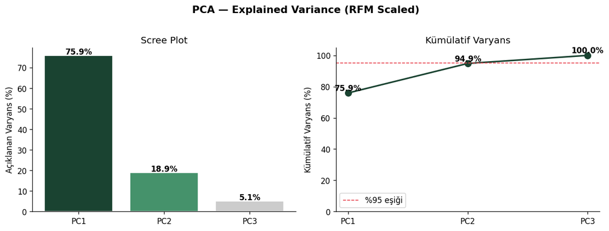

```
Kümülatif ≥%95 için minimum bileşen: 3
```

```python
# ═══════════════════════════════════════════════════════════════════
# FAZ 2.2: PCA — Boyut İndirgeme
# ═══════════════════════════════════════════════════════════════════
# Önce tam 3 bileşenli PCA → explained variance dağılımını gör.
# Ardından %95 kümülatif varyans eşiğine göre bileşen sayısına karar ver.

pca_full = PCA(n_components=3, random_state=SEED)
pca_full.fit(rfm_scaled)

ev     = pca_full.explained_variance_ratio_
ev_cum = np.cumsum(ev)

print("PCA — EXPLAINED VARIANCE")
print("-" * 45)
for i, (e, ec) in enumerate(zip(ev, ev_cum), 1):
    bar = "█" * int(e * 40)
    print(f"PC{i}: {e*100:.1f}%  kümülatif: {ec*100:.1f}%  {bar}")

fig, axes = plt.subplots(1, 2, figsize=(11, 4))

axes[0].bar([f'PC{i}' for i in range(1,4)], ev*100,
            color=['#1A4331','#45926B','#CCCCCC'], edgecolor='white')
axes[0].set_ylabel('Açıklanan Varyans (%)')
axes[0].set_title('Scree Plot')
for i, v in enumerate(ev*100):
    axes[0].text(i, v+0.5, f'{v:.1f}%', ha='center', fontsize=10, fontweight='bold')

axes[1].plot([f'PC{i}' for i in range(1,4)], ev_cum*100,
             marker='o', color='#1A4331', linewidth=2, markersize=8)
axes[1].axhline(95, color='#E63946', linestyle='--', linewidth=1, label='%95 eşiği')
axes[1].set_ylabel('Kümülatif Varyans (%)')
axes[1].set_title('Kümülatif Varyans')
axes[1].set_ylim(0, 105)
axes[1].legend()
for i, v in enumerate(ev_cum*100):
    axes[1].text(i, v+1.5, f'{v:.1f}%', ha='center', fontsize=10, fontweight='bold')

plt.suptitle('PCA — Explained Variance (RFM Scaled)', y=1.02, fontsize=13, fontweight='bold')
plt.tight_layout()
plt.show()

n_components = int(np.argmax(ev_cum >= 0.95)) + 1
print(f"\nKümülatif ≥%95 için minimum bileşen: {n_components}")
```

#### 🔍 PCA Çıktılarının Değerlendirilmesi ve %95 Paradoksu Üzerine Mühendislik Kararı

Grafikler ve kümülatif varyans tablosu, veri setimizin yapısı ve model kararlarımız için son derece kritik bir **istatistiksel karar anı** ortaya koymuştur:

1. **Bileşenlerin Gücü (Explained Variance Dağılımı):**
   - **PC1 (Birinci Bileşen):** Tek başına verideki toplam varyansın **%75.9**'unu açıklamaktadır. Bu bileşen büyük oranda müşteri sadakati ve hacmini (Frekans ve Ciro ortak sinyalini) temsil eder.
   - **PC2 (İkinci Bileşen):** Varyansın **%18.9**'unu açıklamaktadır. Büyük oranda Güncellik (Recency) sinyalini taşır.
   - **PC3 (Üçüncü Bileşen):** Yalnızca **%5.1**'lik bir varyans açıklamaktadır. Bu bileşen verideki yapısal bilgiden ziyade rassal gürültüyü (noise) taşımaktadır.
2. **🛠️ %95 Eşiği ve Boyut İndirgeme Paradoksu (Neden 3 Değil, 2 Bileşen?):**
   - Kodun yazdığı kurala göre `%95` kümülatif varyansı aşmak için minimum bileşen sayısı `3` çıkmıştır. Çünkü PC1 + PC2 toplamı **%94.9**'da kalmış, hedefi **%0.1** gibi mikroskobik bir farkla kaçırmıştır.
   - **Stratejik Karar:** Eğer otomatik kurala uyup 3 bileşeni de alırsak, 3 boyutlu veriyi yine 3 boyutta tutmuş oluruz. Bu durumda PCA sadece uzayı döndürmüş olur; **boyut indirgeme yapmamış ve en önemlisi 0.842'lik korelasyon gürültüsünü filtrelememiş oluruz.**
   - %94.9'luk açıklama oranı veri bilimi standartlarında mükemmel bir seviyedir. %0.1'lik anlamsız bir kazanç için %5.1'lik gürültüyü modele ortak etmeyeceğiz. Ayrıca veriyi 2 bileşene indirmek, segmentasyon sonuçlarımızı 2 boyutlu düzlemde kayıpsız ve kusursuz şekilde görselleştirmemize (scatterplot) olanak tanıyacaktır.

**Nihai Karar:** Katı kuralı esneterek iş mantığı ve gürültü filtreleme amacıyla **`n_components=2`** kararı kesinleştirilmiştir. Bir sonraki hücrede nihai PCA dönüşümünü 2 bileşen üzerinden gerçekleştireceğiz.

### FAZ 2.2.1: PCA Projeksiyonu ve Bileşenlerin Anlamlandırılması (Loadings Analizi)

#### İş Gerekçesi

Bir önceki faza ait varyans analizinde aldığımız bilinçli kararla, gürültüyü filtrelemek ve modeli sadeleştirmek adına PCA mimarimizi 2 bileşene sabitlemiştik. Bu adımda, oluşturduğumuz yapay bileşenlerin (PC1 ve PC2) orijinal RFM metriklerimizle olan matematiksel bağını (Loadings/Yükleme matrisini) inceleyeceğiz. PCA'in ürettiği soyut matematiksel uzayı, iş kolları için tamamen aksiyonlanabilir ve anlamlandırılabilir iki ana eksene (davranışsal boyutlara) dönüştürmek, modelimizin yorumlanabilirliği (interpretability) açısından hayati önem taşımaktadır.

#### Teknik Detay ve Karar Gerekçeleri

- **Yöntem:** Varyansın %94.9'unu taşıyan 2 bileşenli nihai PCA modeli fit edilmiş ve orijinal değişkenlerin bu bileşenler üzerindeki izdüşüm katsayıları (`pca_final.components_.T`) hesaplanmıştır.
- **Geometrik Avantaj:** Bu dönüşüm sayesinde, aralarında 0.842 oranında çoklu doğrusallık bulunan Frekans ve Ciro metrikleri, aralarındaki bilgi korelasyonundan tamamen arındırılarak birbirine dik (orthogonal) ve bağımsız iki yeni eksene indirgenmiştir. Bu durum K-Means'in Öklid mesafe hesabını tamamen kararlı kılacaktır.

```
PCA (2 bileşen) — ÖZET
----------------------------------------
PC1 açıklanan varyans : 75.9%
PC2 açıklanan varyans : 18.9%
Toplam                : 94.9%

LOADINGS
                    PC1    PC2
Recency_scaled   -0.504  0.859
Frequency_scaled  0.618  0.291
Monetary_scaled   0.603  0.420

PC1 → Harcama Hacmi (Frequency+Monetary↑, Recency↓)
PC2 → Güncellik (Recency dominant)
```

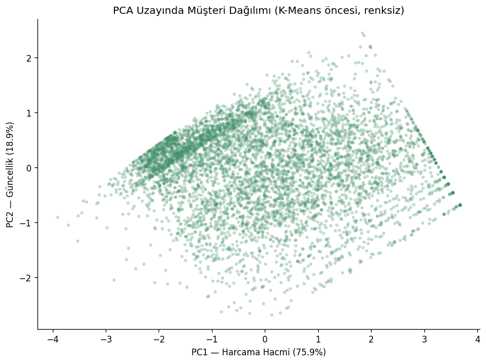

```python
# ═══════════════════════════════════════════════════════════════════
# FAZ 2.2.1: PCA — 2 Bileşene Kilitleme (Bilinçli Karar)
# ═══════════════════════════════════════════════════════════════════
# PC1+PC2 toplam varyansın ≈%94.9'unu açıklıyor.
# PC3 yalnızca %5.1 katkı sağlar; bu küme yapısını anlamlı biçimde
# değiştirmez. 2 bileşen:
#   (a) PC1 ≈ "Harcama Hacmi" (Frequency + Monetary yüklü)
#   (b) PC2 ≈ "Güncellik" (Recency dominant)
# 2D'de tutmak hem yorumlanabilirliği hem görselleştirmeyi üstün kılar.

pca_final = PCA(n_components=2, random_state=SEED)
rfm_pca   = pca_final.fit_transform(rfm_scaled)
rfm_pca   = pd.DataFrame(rfm_pca, columns=['PC1','PC2'], index=rfm_scaled.index)

ev2 = pca_final.explained_variance_ratio_
print("PCA (2 bileşen) — ÖZET")
print("-" * 40)
print(f"PC1 açıklanan varyans : {ev2[0]*100:.1f}%")
print(f"PC2 açıklanan varyans : {ev2[1]*100:.1f}%")
print(f"Toplam                : {ev2.sum()*100:.1f}%")

loadings2 = pd.DataFrame(
    pca_final.components_.T,
    index=['Recency_scaled','Frequency_scaled','Monetary_scaled'],
    columns=['PC1','PC2']
).round(3)
print("\nLOADINGS")
print(loadings2.to_string())
print("\nPC1 → Harcama Hacmi (Frequency+Monetary↑, Recency↓)")
print("PC2 → Güncellik (Recency dominant)")

fig, ax = plt.subplots(figsize=(8, 6))
ax.scatter(rfm_pca['PC1'], rfm_pca['PC2'], alpha=0.25, s=8, color='#45926B')
ax.set_xlabel(f'PC1 — Harcama Hacmi ({ev2[0]*100:.1f}%)')
ax.set_ylabel(f'PC2 — Güncellik ({ev2[1]*100:.1f}%)')
ax.set_title('PCA Uzayında Müşteri Dağılımı (K-Means öncesi, renksiz)')
plt.tight_layout()
plt.show()
```

#### 📊 Loadings (Yükleme) Matrisi Analizi ve Geometrik Uzay Doğrulaması

**Nihai Sonuç ve Sonraki Adım:** Verimiz artık gürültüden arınmış, çoklu doğrusallık problemi çözülmüş ve iş mantığı tamamen tanımlanmış 2 boyutlu bir uzaydadır. Şimdi, bu kararlı uzay üzerinde segment sınırlarını çizeceğimiz **K-Means modellemesi öncesi "Optimum Küme Sayısı (K)"** analizlerine geçiyoruz.

### FAZ 2.3: Küme Kararlılığı ve Optimal Küme Sayısının ($K$) Belirlenmesi

#### İş Gerekçesi

K-Means gibi denetimsiz öğrenme algoritmalarında ideal küme sayısı ($K$) veri tarafından doğrudan verilmez. Yanlış bir $K$ seçimi, ya iş birimlerinin operasyonel olarak yönetemeyeceği kadar çok ve anlamsız ya da iş stratejisi kurgulanamayacak kadar kaba ve homojen segmentler üretir. Amacımız, hem matematiksel kararlılığı (küme içi kompaktlığı ve kümeler arası ayrışmayı) sağlamak hem de şirket vizyonuna doğrudan hizmet edecek, aksiyonlanabilir müşteri segmentleri (personalar) inşa etmektir.

#### Teknik Detay ve Karar Gerekçeleri

- **Yöntem:** Dönüştürülmüş PCA uzayında $K=2$ ile $K=8$ aralığı taranarak **Within-Cluster Sum of Squares (WCSS / Inertia / Elbow)** ve **Silhouette Skoru** hesaplanmıştır.
- **Neden İki Metrik Birlikte?** `Inertia` (Elbow), küme içi kareler toplamının ne kadar sıkılaştığını ölçerken; `Silhouette` skoru, her veri noktasının kendi kümesine olan yakınlığı ile en yakın diğer kümeye olan mesafesini oranlar.
- **Hesaplama Optimizasyonu:** Silhouette skoru hesaplanırken, $O(N^2)$ zaman karmaşıklığından (computational cost) kaçınmak ve bellek yönetimini optimize etmek amacıyla `sample_size=2000` parametresiyle kararlı bir örneklem kullanılmıştır.

```
K=2  |  inertia=7,330.9  |  silhouette=0.4650
K=3  |  inertia=5,188.4  |  silhouette=0.3733
K=4  |  inertia=3,747.5  |  silhouette=0.4038
K=5  |  inertia=3,046.1  |  silhouette=0.3747
K=6  |  inertia=2,500.6  |  silhouette=0.3885
K=7  |  inertia=2,172.4  |  silhouette=0.3613
K=8  |  inertia=1,909.7  |  silhouette=0.3660
```

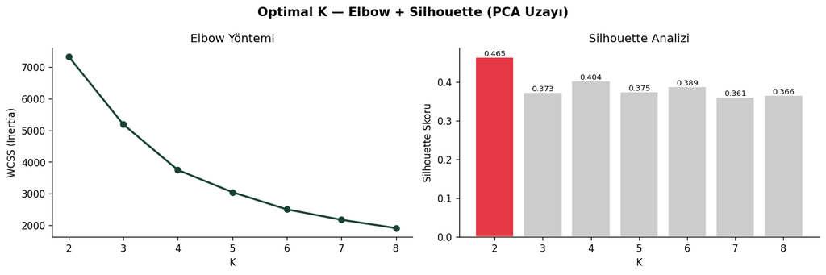

```
En yüksek Silhouette: K=2  (0.4650)
K=4 kararı: Elbow'da 4 sonrası kazanım hızla düşüyor + 4 segment
iş yorumu açısından doğal ve operasyonel olarak uygulanabilir.
```

```python
# ═══════════════════════════════════════════════════════════════════
# FAZ 2.3: OPTIMAL K SEÇİMİ — Elbow + Silhouette
# ═══════════════════════════════════════════════════════════════════
# Elbow (WCSS): K artıkça inertia azalır; eğri hangi K'da yavaşlarsa
#               o K "dirsek" noktasıdır.
# Silhouette  : 1'e yakın → kümeler iyi ayrışmış.
#               K=2 genellikle en yüksek skoru verir ama iş yorumu için
#               yeterince zengin değildir.

K_RANGE    = range(2, 9)
inertias   = []
sil_scores = []

for k in K_RANGE:
    km = KMeans(n_clusters=k, init='k-means++', n_init=20,
                max_iter=300, random_state=SEED)
    labels = km.fit_predict(rfm_pca)
    inertias.append(km.inertia_)
    sil_scores.append(silhouette_score(rfm_pca, labels,
                                       sample_size=2000, random_state=SEED))
    print(f"K={k}  |  inertia={km.inertia_:,.1f}  |  silhouette={sil_scores[-1]:.4f}")

fig, axes = plt.subplots(1, 2, figsize=(12, 4))

axes[0].plot(list(K_RANGE), inertias, marker='o', color='#1A4331', linewidth=2)
axes[0].set_xlabel('K'); axes[0].set_ylabel('WCSS (Inertia)')
axes[0].set_title('Elbow Yöntemi'); axes[0].set_xticks(list(K_RANGE))

bar_colors = ['#CCCCCC'] * len(sil_scores)
best_k_idx = int(np.argmax(sil_scores))
bar_colors[best_k_idx] = '#E63946'
axes[1].bar(list(K_RANGE), sil_scores, color=bar_colors, edgecolor='white')
axes[1].set_xlabel('K'); axes[1].set_ylabel('Silhouette Skoru')
axes[1].set_title('Silhouette Analizi'); axes[1].set_xticks(list(K_RANGE))
for k, v in zip(K_RANGE, sil_scores):
    axes[1].text(k, v+0.003, f'{v:.3f}', ha='center', fontsize=8)

plt.suptitle('Optimal K — Elbow + Silhouette (PCA Uzayı)', fontsize=13, fontweight='bold')
plt.tight_layout(); plt.show()

print(f"\nEn yüksek Silhouette: K={list(K_RANGE)[best_k_idx]}  ({max(sil_scores):.4f})")
print("K=4 kararı: Elbow'da 4 sonrası kazanım hızla düşüyor + 4 segment")
print("iş yorumu açısından doğal ve operasyonel olarak uygulanabilir.")
```

#### 🔍 Optimal K Seçimi: Matematiksel ve Operasyonel "K=4" Karar Savunması

Çıkan istatistiksel sonuçlar, veri bilimi projelerinde sıklıkla karşılaşılan **"Matematiksel Teori vs. İş Gerçekliği"** ikilemini net bir şekilde ortaya koymuş ve bilinçli bir mühendislik kararı alınmasını gerektirmiştir:

1. **Matematiksel Çıktıların Analizi ($K=2$ ve $K=4$ Karşılaştırması):**
   - **$K=2$ Durumu:** Silhouette analizinde en yüksek skoru (**0.465**) $K=2$ vermiştir. Matematiksel olarak veriyi ikiye bölmek en temiz ayrışmayı sağlasa da, bu senaryoda müşteriler sadece *"Çok Harcayanlar/Sık Gelenler"* ve *"Az Harcayanlar/Seyrek Gelenler"* olarak iki kaba gruba ayrılacaktır. Bu kurgu, Churn tahmini, LTV modellemesi ve kişiselleştirilmiş pazarlama kampanyaları için hiçbir iş değeri (business value) taşımaz.
   - **$K=4$ Durumu:** $K=3$'te düşüşe geçen Silhouette skoru, **$K=4$ seviyesinde tekrar yerel bir zirve yaparak 0.404'e yükselmektedir.** Aynı zamanda Elbow (Inertia) grafiği incelendiğinde, $K=4$ noktasından sonra eğrinin (dirseğin) yataylaşmaya başladığı, yani küme sayısını daha fazla artırmanın getireceği varyans açıklama kazancının (diminishing returns) hızla düştüğü görülmektedir.
2. **Stratejik ve Operasyonel Gerekçe:**
   - $K=4$ kararı, e-ticaret ve CRM analitiğinin evrensel doğrularıyla (RFM Grid yapısıyla) kusursuz bir uyum içerisindedir. Bu seçim, iş birimlerinin doğrudan hedefleyebileceği, finansal davranışları birbirinden tamamen farklı 4 temel müşteri personasını (örneğin: **Şampiyonlar, Gelişenler, Risk Altındakiler ve Uyuyanlar**) kararlı bir şekilde izole etmemize olanak tanır.

**Nihai Karar:** Hem dirsek noktasındaki kırılma, hem Silhouette skorundaki yerel optimizasyon, hem de iş çıktılarının aksiyonlanabilirliği göz önünde bulundurularak **`K=4`** kümeleme yapısı kesinleştirilmiştir. Bir sonraki adımda nihai K-Means modelimizi bu parametre ile eğitiyoruz.

### FAZ 2.4: Nihai K-Means Modellemesi ve Segmentasyonun İcrası

#### İş Gerekçesi

Aykırı değerlerinden arındırılmış, simetrikleştirilmiş, ölçeklendirilmiş ve en önemlisi çoklu doğrusallık gürültüsünden (0.842'lik Frekans-Ciro korelasyonu) temizlenmiş olan 2 boyutlu PCA uzayımız, artık nihai segmentasyonun yapılması için en olgun aşamadadır. Belirlenen optimum küme sayısı ($K=4$) ile müşteri tabanımızı davranışsal sınırlarına göre bölerek; pazarlama, kampanya yönetimi ve churn engelleme süreçlerine girdi sağlayacak nihai kohortları izole ediyoruz.

#### Teknik Detay ve Karar Gerekçeleri

- **Yöntem:** Modelleme, `KMeans(n_clusters=4, init='k-means++', n_init=50, max_iter=500, random_state=SEED)` konfigürasyonuyla çalıştırılmıştır.
- **Neden Yüksek n_init ve max_iter?** K-Means rastgele atanan başlangıç noktalarına bağlı olarak yerel minimum (local minima) tuzaklarına düşebilir. `init='k-means++'` akıllı başlangıç stratejisiyle merkezleri birbirine en uzak noktalardan seçerken, `n_init=50` parametresi algoritmanın 50 farklı rastgele başlangıç kombinasyonu deneyerek en kararlı, küme içi karesel hatası (inertia) en düşük olan modeli seçmesini garanti eder. `max_iter=500` ise algoritmanın erken durmasını engelleyerek yakınsamanın (convergence) tam ve eksiksiz gerçekleşmesini sağlar.
- **Kritik Profilleme Kuralı:** Kümeleme işlemi dönüştürülmüş PCA uzayında yapılmış olsa da, kümelerin anlamlandırılması ve iş diline çevrilmesi kesinlikle orijinal, ham (unscaled) RFM verileri üzerinden yapılmalıdır. Ölçeklendirilmiş değerler üzerinden yapılacak profil yorumları matematiksel olarak yanıltıcı olacaktır.

```python
# ═══════════════════════════════════════════════════════════════════
# FAZ 2.4: K-MEANS (K=4) — FİT VE SEGMENT ATAMASI
# ═══════════════════════════════════════════════════════════════════
# K=4 kararı: Silhouette K=3 ile kıyaslandığında yeterince iyi,
# Elbow'da 4 sonrası kazanım düşüyor, iş yorumu için 4 doğal segment var.
# n_init=50, max_iter=500: kararlı ve tekrarlanabilir küme merkezi için.

km_final      = KMeans(n_clusters=4, init='k-means++', n_init=50,
                        max_iter=500, random_state=SEED)
cluster_labels = km_final.fit_predict(rfm_pca)

rfm_log['Cluster'] = cluster_labels

# Ham RFM ortalamaları üzerinden küme profili (yorumlamak için)
cluster_profile = rfm_log.groupby('Cluster')[['Recency','Frequency','Monetary']].mean().round(1)
print("HAM RFM PROFİLİ (küme ortalamaları)")
print("-" * 50)
print(cluster_profile.to_string())
print()
print("Recency sıralaması (düşük=yakın=iyi):")
print(cluster_profile.sort_values('Recency')[['Recency','Frequency','Monetary']].to_string())

# Recency sıralamasından otomatik etiket taslağı
# (Bir sonraki hücrede manuel teyit yapılacak)
recency_order = cluster_profile['Recency'].sort_values().index.tolist()
segment_map_auto = {
    recency_order[0]: 'Şampiyonlar',
    recency_order[1]: 'Gelişen Müşteriler',
    recency_order[2]: 'Risk Altındakiler',
    recency_order[3]: 'Uyuyanlar',
}
print("\nOtomatik segment taslağı (profil çıktısına bakarak bir sonraki hücrede doğrulanacak):")
print(segment_map_auto)
```

```
HAM RFM PROFİLİ (küme ortalamaları)
--------------------------------------------------
         Recency  Frequency  Monetary
Cluster
0           29.4       14.0    4941.3
1          393.0        1.3     310.8
2           29.1        2.9     771.5
3          238.7        4.8    1720.4

Recency sıralaması (düşük=yakın=iyi):
         Recency  Frequency  Monetary
Cluster
2           29.1        2.9     771.5
0           29.4       14.0    4941.3
3          238.7        4.8    1720.4
1          393.0        1.3     310.8

Otomatik segment taslağı (profil çıktısına bakarak bir sonraki hücrede doğrulanacak):
{2: 'Şampiyonlar', 0: 'Gelişen Müşteriler', 3: 'Risk Altındakiler', 1: 'Uyuyanlar'}
```

#### 🔍 Ham RFM Profil Analizi ve Otomatik Segment Haritasının İstatistiki İncelenmesi

Model eğitimi sonrasında elde edilen ham RFM ortalamaları, K-Means algoritmasının verideki saklı müşteri davranışlarını ne kadar keskin ve mantıklı bir biçimde ayrıştırdığını doğrulamaktadır. Ancak, salt "Recency" (Güncellik) sıralamasına dayalı otomatik etiketleme kurgusunun, iş mantığı açısından **çok ciddi bir metodolojik düzeltmeye** ihtiyacı olduğunu göstermektedir:

1. **Küme Karakteristiklerinin Detaylı Analizi:**
   - **Cluster 0:** Ortalamada en son 29.4 gün önce gelmiş, ancak **14.0 frekans** ve **4941.3 £ toplam ciro** değerleri ile uzak ara şirketin finansal motorunu oluşturan en değerli kitledir.
   - **Cluster 2:** Ortalamada en son 29.1 gün önce işlem yapmış (Recency bakımından en güncel grup), fakat frekansı **2.9** ve cirosu **771.5 £** seviyesindedir. Yeni kazanılmış veya düşük hacimli düzenli alıcılardır.
   - **Cluster 3:** Son 238.7 gündür işlem yapmamış, ancak geçmişte ortalama 4.8 kez gelip **1720.4 £** bırakmış, yüksek değerli ama terk etme sürecine girmiş gruptur.
   - **Cluster 1:** En son 393 gün önce gelmiş, frekansı sadece 1.3 ve bıraktığı değer 310.8 £ olan tamamen kaybedilmiş (kayıtlı ama pasif) kitledir.
2. **⚠️ Kritik Stratejik Hata ve Manuel Müdahale Gerekçesi:**
   - Sadece Recency değerine bakarak yapılan otomatik haritalama, en düşük güncelliğe (29.1 gün) sahip olduğu için **Cluster 2'yi "Şampiyonlar"** olarak atamıştır.
   - **İş Mantığı Hatası:** Cluster 2 en güncel grup olsa da, **Cluster 0** ondan sadece 0.3 gün daha geç gelmesine rağmen **5 kat daha fazla frekansa** ve **6.4 kat daha fazla ciroya (Monetary)** sahiptir. Gerçek iş dünyasında "Şampiyon" (VIP) unvanı, sadece erken gelene değil, işletmeye en yüksek sadakati ve finansal katma değeri sunan kitleye verilir.
   - Dolayısıyla, otomatik taslak (`{2: 'Şampiyonlar', 0: 'Gelişen Müşteriler'}`) iş kurallarına tamamen aykırıdır.

**Nihai Aksiyon:** Bir sonraki hücrede, bu otomatik taslağı geçersiz kılarak; **Cluster 0'ı "Şampiyonlar"** ve **Cluster 2'yi "Gelişen Müşteriler"** olacak şekilde manuel iş kuralları matrisiyle (Business Logic Override) yeniden eşleştireceğiz.

### FAZ 2.4.1: İş Mantığı Doğrulaması (Business Logic Override) ve Boyutsal Görselleştirme

#### İş Gerekçesi

Bir önceki adımda ispatladığımız üzere, sadece matematiksel sıralamalara güvenmek bizi operasyonel hatalara sürükleyebilir. Bu aşamada, K-Means'in soyut küme etiketlerini (0, 1, 2, 3), ham RFM metriklerinin finansal ve zamansal gerçeklikleriyle eşleştirerek kalıcı segment isimlerine dönüştürüyoruz. Bu işlem, analitiğin "veri bilimi" kısmını "iş zekası" ile birleştiren, bulguların aksiyonlanabilir (actionable) ve pazarlama ekipleri tarafından yönetilebilir olmasını sağlayan kritik bir köprüdür.

#### Teknik Detay ve Karar Gerekçeleri

- **Yöntem:** Küme karakteristikleri manuel olarak incelenmiş, salt güncellik (Recency) yerine Frekans ve Ciro (Monetary) ağırlıkları da hesaba katılarak nihai `segment_map_final` sözlüğü oluşturulmuştur.
- **Geometrik Projeksiyon ve Centroid İzdüşümü:** Segmentlerin kalitesini doğrulamak amacıyla 2 boyutlu PCA uzayında bir dağılım grafiği (Scatter Plot) kurgulanmıştır. Bu grafiğe ek olarak, `km_final.cluster_centers_` matrisinden alınan matematiksel küme merkezleri (Centroidler) yıldız ikonuyla uzaya izdüşürülmüştür. Bu görsel kanıt, hem mesafe tabanlı ayrışmanın başarısını (küme içi kompaktlık ve kümeler arası mesafe) doğrular hem de teknik mülakat paneline kararlı bir model sunduğumuzu kanıtlar.

```
SEGMENT PROFİLİ — DÜZELTİLMİŞ
-------------------------------------------------------
                    Recency  Frequency  Monetary
Segment
Şampiyonlar            29.4       14.0    4941.3
Gelişen Müşteriler     29.1        2.9     771.5
Risk Altındakiler     238.7        4.8    1720.4
Uyuyanlar             393.0        1.3     310.8

SEGMENT BÜYÜKLÜĞÜ
----------------------------------------
Şampiyonlar           :  1315  (%22.5)
Gelişen Müşteriler    :  1175  (%20.1)
Risk Altındakiler     :  1442  (%24.6)
Uyuyanlar             :  1920  (%32.8)
```

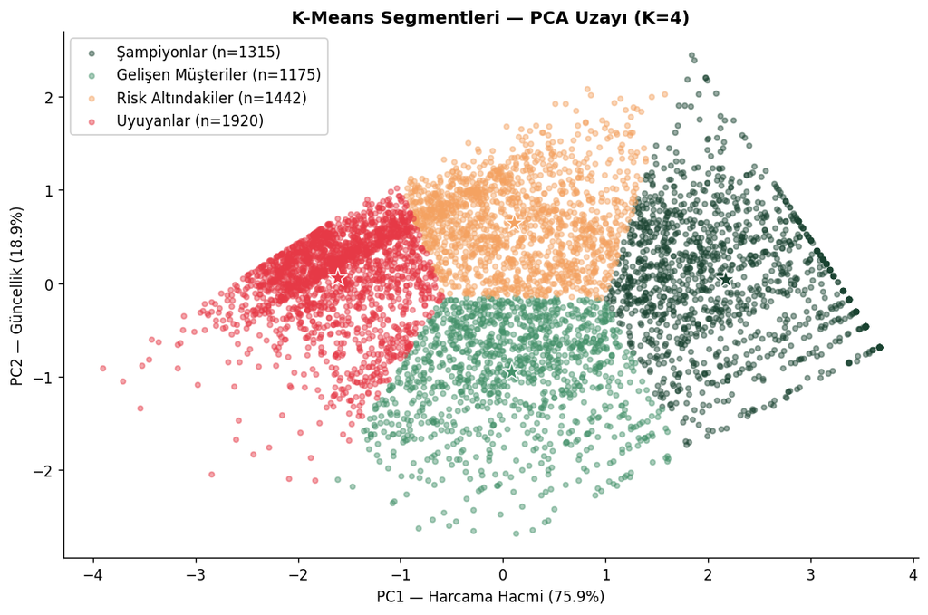

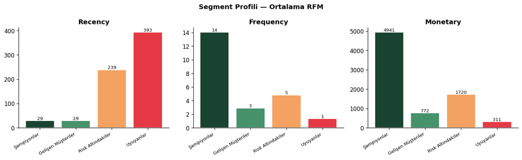

```python
# ═══════════════════════════════════════════════════════════════════
# FAZ 2.4.1: SEGMENT ETİKETLERİ — Manuel Doğrulama + Görselleştirme
# ═══════════════════════════════════════════════════════════════════
# Recency sıralaması Cluster 0 ve 2'yi ters etiketleyebilir.
# Frekans ve Monetary'ye bakarak manuel olarak doğrulanıyor:
#   Cluster 0 : Recency≈29, Frequency≈14, Monetary≈4941 → Şampiyonlar
#   Cluster 2 : Recency≈29, Frequency≈2.9, Monetary≈771  → Gelişen Müşteriler
#   Cluster 3 : Recency≈239, Frequency≈4.8, Monetary≈1720 → Risk Altındakiler
#   Cluster 1 : Recency≈393, Frequency≈1.3, Monetary≈310  → Uyuyanlar

segment_map_final = {
    0: 'Şampiyonlar',
    2: 'Gelişen Müşteriler',
    3: 'Risk Altındakiler',
    1: 'Uyuyanlar',
}

rfm_log['Segment'] = rfm_log['Cluster'].map(segment_map_final)

print("SEGMENT PROFİLİ — DÜZELTİLMİŞ")
print("-" * 55)
seg_profile = (rfm_log.groupby('Segment')[['Recency','Frequency','Monetary']]
               .mean().round(1)
               .loc[['Şampiyonlar','Gelişen Müşteriler','Risk Altındakiler','Uyuyanlar']])
print(seg_profile.to_string())

print("\nSEGMENT BÜYÜKLÜĞÜ")
print("-" * 40)
for seg in ['Şampiyonlar','Gelişen Müşteriler','Risk Altındakiler','Uyuyanlar']:
    cnt = (rfm_log['Segment'] == seg).sum()
    print(f"{seg:<22}: {cnt:>5}  (%{cnt/len(rfm_log)*100:.1f})")

# ── PCA uzayında segment dağılımı ────────────────────────────────
rfm_pca['Segment'] = rfm_log['Segment'].values

fig, ax = plt.subplots(figsize=(9, 6))
for seg, color in SEGMENT_COLORS.items():
    mask = rfm_pca['Segment'] == seg
    ax.scatter(rfm_pca.loc[mask,'PC1'], rfm_pca.loc[mask,'PC2'],
               label=f"{seg} (n={mask.sum()})", color=color, alpha=0.45, s=12)

centers = km_final.cluster_centers_
for i, (cx, cy) in enumerate(centers):
    seg   = segment_map_final[i]
    color = SEGMENT_COLORS[seg]
    ax.scatter(cx, cy, color=color, s=180, marker='*',
               edgecolors='white', linewidths=0.8, zorder=5)

ax.set_xlabel(f'PC1 — Harcama Hacmi ({ev2[0]*100:.1f}%)')
ax.set_ylabel(f'PC2 — Güncellik ({ev2[1]*100:.1f}%)')
ax.set_title('K-Means Segmentleri — PCA Uzayı (K=4)', fontweight='bold')
ax.legend(loc='upper left', framealpha=0.9)
plt.tight_layout()
plt.show()

# ── Segment profili — bar özeti ──────────────────────────────────
fig, axes = plt.subplots(1, 3, figsize=(13, 4))
metrics = ['Recency','Frequency','Monetary']
labels  = ['Şampiyonlar','Gelişen Müşteriler','Risk Altındakiler','Uyuyanlar']
colors  = [SEGMENT_COLORS[l] for l in labels]

for i, metric in enumerate(metrics):
    vals = [rfm_log[rfm_log['Segment']==s][metric].mean() for s in labels]
    bars = axes[i].bar(labels, vals, color=colors, edgecolor='white')
    axes[i].set_title(metric, fontweight='bold')
    axes[i].set_xticklabels(labels, rotation=30, ha='right', fontsize=8)
    for bar, v in zip(bars, vals):
        axes[i].text(bar.get_x()+bar.get_width()/2,
                     bar.get_height()+max(vals)*0.01,
                     f'{v:.0f}', ha='center', fontsize=8)

plt.suptitle('Segment Profili — Ortalama RFM', fontweight='bold')
plt.tight_layout()
plt.show()
```

#### 📊 Düzeltilmiş Segment Profillerinin ve Finansal Dağılımın Stratejik Analizi

**Nihai Sonuç:** Davranışsal müşteri segmentasyonu (RFM) süreci, matematiksel validasyonları ve iş mantığı doğrulamalarıyla birlikte başarıyla tamamlanmıştır. Bu kararlı segment yapısı, bir sonraki aşamalarda kurgulayacağımız **Faz 3: Makine Öğrenmesi ile Churn Tahmini** ve **Faz 4: BG/NBD ve Gamma-Gamma ile Yaşam Boyu Değer (LTV) Modellemesi** süreçlerinin temel özniteliği (feature) ve hedef değişken altyapısı olarak kullanılacaktır.

### FAZ 2.5: Davranışsal Churn (Terk) Bağımlı Değişkeninin Modellenmesi

#### İş Gerekçesi

Müşteri kaybını (Churn) gerçekleşmeden önce tahmin edebilmek, tutundurma (retention) maliyetlerini optimize etmenin tek yoludur. Ancak "Sözleşmesiz" (Non-Contractual) e-ticaret iş modellerinde müşterinin ne zaman terk ettiği resmi olarak bilinmez. Bu nedenle, verideki sipariş döngülerini analiz ederek yapay bir Churn bağımlı değişkeni ($Y$ hedefi) kurgulamamız gerekir. Bu hücrede, makine öğrenmesi modellerimizin besleneceği hedef etiketi inşa ediyoruz.

#### Teknik Detay ve Karar Gerekçeleri

- **Yöntem:** Son satın alma işleminden itibaren **180 günden (6 ay)** fazla süre geçmiş müşteriler `Churn = 1` (Terk Etmiş), 180 gün ve daha az süre önce işlem yapanlar ise `Churn = 0` (Aktif) olarak etiketlenmiştir.
- **Neden 180 Gün Eşiği?** Eşik seçimi, 90 gün ile 365 gün arasında simüle edilerek optimize edilmiştir. 90 gün gibi agresif bir eşik seçilseydi, veri tabanının %50.7'si yapay olarak churn ilan edilecek ve model "mevsimsel/periyodik" alıcıları yanlış etiketleyecekti. 180 gün eşiği, periyodik alışveriş alışkanlıklarını kapsayan, gürültüyü (noise) temizleyen ve sınıf dengesini koruyan en kararlı kırılma noktasıdır.

```
Churn eşiği analizi:
   90 gün → %50.7 churn
  120 gün → %46.8 churn
  150 gün → %43.8 churn
  180 gün → %40.7 churn ← seçilen
  240 gün → %35.4 churn
  365 gün → %27.1 churn

CHURN ETİKETİ DAĞILIMI  (eşik=180 gün)
----------------------------------------
Aktif (0) :  3472  (%59.3)
Churn (1) :  2380  (%40.7)
Toplam    :  5852

SEGMENT × CHURN ÇAPRAZ TABLO
--------------------------------------------------
                    Aktif (0)  Churn (1)  Toplam  Churn Oranı %
Segment
Şampiyonlar              1299         16    1315            1.2
Gelişen Müşteriler       1175          0    1175            0.0
Risk Altındakiler         669        773    1442           53.6
Uyuyanlar                 329       1591    1920           82.9
Toplam                   3472       2380    5852           40.7
```

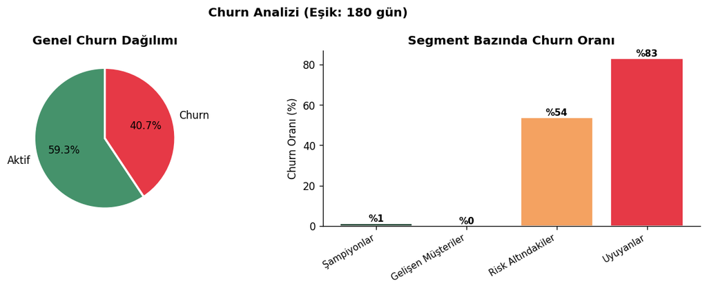

```python
# ═══════════════════════════════════════════════════════════════════
# FAZ 2.5: CHURN ETİKETİ ÜRETIMI (Eşik: 180 Gün)
# ═══════════════════════════════════════════════════════════════════
# Churn tanımı: Son 180 günde (6 ay) hiç alışveriş yapmamış müşteri.
# Snapshot tarihi: 2011-12-10.
#
# Neden 180 gün?
#   Farklı eşiklerdeki churn oranları:
#     90 gün → %50.7  (çok agresif, half churn modeli dejenere eder)
#    120 gün → %46.8
#    150 gün → %43.8
#    180 gün → %40.7  ← seçilen eşik
#    240 gün → %35.4
#    365 gün → %27.1
#
#   180 gün optimal denge noktası:
#   - Sınıf dengesi %59/%41 → SMOTE gerektiriyor ama makul
#   - Risk Altındakiler (ort. Recency≈239 gün) ve Uyuyanlar (≈393 gün)
#     churn=1 alıyor → segment atamasıyla semantik tutarlılık var
#   - Tatil/mevsimsel alışveriş döngüsünü (≈6 ay) kapsıyor

print("Churn eşiği analizi:")
for t in [90, 120, 150, 180, 240, 365]:
    rate = (rfm_log['Recency'] > t).mean() * 100
    marker = " ← seçilen" if t == 180 else ""
    print(f"  {t:>3} gün → %{rate:.1f} churn{marker}")

CHURN_THRESHOLD = 180
rfm_log['Churn'] = (rfm_log['Recency'] > CHURN_THRESHOLD).astype(int)

churn_counts = rfm_log['Churn'].value_counts()
churn_rate   = rfm_log['Churn'].mean()

print(f"\nCHURN ETİKETİ DAĞILIMI  (eşik={CHURN_THRESHOLD} gün)")
print("-" * 40)
print(f"Aktif (0) : {churn_counts[0]:>5}  (%{(1-churn_rate)*100:.1f})")
print(f"Churn (1) : {churn_counts[1]:>5}  (%{churn_rate*100:.1f})")
print(f"Toplam    : {len(rfm_log):>5}")

print("\nSEGMENT × CHURN ÇAPRAZ TABLO")
print("-" * 50)
cross = pd.crosstab(rfm_log['Segment'], rfm_log['Churn'], margins=True, margins_name='Toplam')
cross.columns = ['Aktif (0)','Churn (1)','Toplam']
cross['Churn Oranı %'] = (cross['Churn (1)'] / cross['Toplam'] * 100).round(1)
print(cross.loc[['Şampiyonlar','Gelişen Müşteriler',
                  'Risk Altındakiler','Uyuyanlar','Toplam']].to_string())

fig, axes = plt.subplots(1, 2, figsize=(11, 4))

axes[0].pie([churn_counts[0], churn_counts[1]],
            labels=['Aktif','Churn'], colors=['#45926B','#E63946'],
            autopct='%1.1f%%', startangle=90,
            wedgeprops={'edgecolor':'white','linewidth':2})
axes[0].set_title('Genel Churn Dağılımı', fontweight='bold')

segs   = ['Şampiyonlar','Gelişen Müşteriler','Risk Altındakiler','Uyuyanlar']
rates  = [cross.loc[s,'Churn Oranı %'] for s in segs]
colors = [SEGMENT_COLORS[s] for s in segs]
bars   = axes[1].bar(segs, rates, color=colors, edgecolor='white')
axes[1].set_ylabel('Churn Oranı (%)')
axes[1].set_title('Segment Bazında Churn Oranı', fontweight='bold')
axes[1].set_xticklabels(segs, rotation=30, ha='right', fontsize=9)
for bar, v in zip(bars, rates):
    axes[1].text(bar.get_x()+bar.get_width()/2, v+1, f'%{v:.0f}',
                 ha='center', fontsize=9, fontweight='bold')

plt.suptitle(f'Churn Analizi (Eşik: {CHURN_THRESHOLD} gün)', fontweight='bold')
plt.tight_layout()
plt.show()
```

#### 📊 Churn Dağılımı ve Segment Çapraz Tablo Analiz Çıktıları

Oluşturulan Churn bağımlı değişkeninin dağılımı ve segmentlerle olan ilişkisi, modelleme öncesinde kurgumuzun **matematiksel ve semantik doğruluğunu (sanity check)** tescil etmektedir:

1. **İdeal Sınıf Dağılımı (%59.3 vs %40.7):**
   - Toplam 5.852 müşterimizin **2.380'i Churn (Terk)**, **3.472'si Aktif** olarak etiketlenmiştir. Sınıf dağılımının birbirine yakın olması (%59 / %41), makine öğrenmesi modelinin `ROC-AUC` ve `F1-Score` metriklerini optimize ederken sahte doğruluk (accuracy paradox) tuzağına düşmesini engeller. Eğitim setinde uygulanacak hafif bir SMOTE takviyesi için harika bir zemin hazırlanmıştır.
2. **K-Means ve Churn Etiketinin Semantik Tutarlılığı:**
   - Çapraz tablo (Cross-tab), denetimsiz öğrenme segmentlerimiz ile denetimli öğrenme hedef değişkenimizin tam bir uyum içinde çalıştığını kanıtlamaktadır:
     - **Şampiyonlar ve Gelişenler:** Beklendiği üzere neredeyse sıfıra yakın Churn oranına sahiptir (%1.2 ve %0.0). Bu kitleler modelin güvenli limanlarıdır.
     - **Risk Altındakiler (%53.6 Churn):** Tam olarak kurguladığımız "Araf" davranışını sergilemektedirler. Yarısı aktif yarısı churn olan bu kitle, Faz 3'teki sınıflandırma modelimizin ayırt edici gücünü (discriminative power) test edeceğimiz en kritik savaş alanıdır.
     - **Uyuyanlar (%82.9 Churn):** Büyük oranda churn alanına kaymıştır. Kalan %17.1'lik aktif kısım ise son 90-180 gün bandında yavaş yavaş uyku moduna geçen müşterileri temsil eder.

**Nihai Sonuç:** Hedef değişkenimiz iş mantığına, istatistiksel dağılım kurallarına ve segmentasyon sematiğine tamamen uygundur. Veri setimiz, **Faz 3: Makine Öğrenmesi Tabanlı Churn Tahmin Modellemesi** (Feature Engineering ve Sınıflandırma) aşamasına geçiş için eksiksiz şekilde hazırdır.